# Two Stage MCMC

Alexander Berliner

2025-10-06

## 1 Overview of Two-stage MCMC for Bayesian Inference of Spatio-temporal Ordinal Data

In this document we provide an overview of two-stage MCMC and why it would be advantageous to single-stage MCMC if we’re doing Bayesian inference of large spatio-temporal ordinal data. This work follows the comparisons study in *Two-stage MCMC for Fast Bayesian Inference of Large Spatio-temporal Ordinal Data, with Application to US Drought* by Hepler et al. [2].

## 2 Why Bayesian?

In spatio-temporal data with complex dependency structures, we might choose a Bayesian approach because:

- It allows us to quantify uncertainty of parameters based off their full distributions.
- It incorporates hierarchical structures of random effects.
- Our prior information could improve inference.

In practice, we estimate the probability distributions of these unknown parameters using numerical sampling techniques called MCMC.

## 3 Why two-stage MCMC?

Two-stage MCMC first partitions the data into subsets, runs a local MCMC on each partition to estimate their parameters, and then in the second stage summarizes the posterior estimates of the parameters to output aggregated distributions. While running a single MCMC on an entire, voluminous dataset would be most optimal, it may be computationally infeasible due to finite memory resources. The two-stage method breaks the dataset into manageable, parallizable sets. Hepler et al. demonstrate that this recursive approach is computationally more efficient and eliminates the need for approximations or dimension reduction.

## 4 The data

In their paper, Hepler et al. compare single and two stage MCMC on ordinal lattice data where the response indicates drought severity recorded in a spatial lattice.

The spatio-temporal data, USDMDataAvg.csv, can be found [here](https://datadryad.org/stash/dataset/doi:10.5061/dryad.g1jwstqw7). Erhardt et al. created this dataset from the original US Drought Monitor (USDM) from continuous shape files to a discretized spatial support defined by grid cells of size 0.5 degrees latitude by 0.5 degrees longitude [1]. The response variable is an ordinal measure of the severity of drought in the United States. The USDM levels are:

- 0 = no drought
- D0 = abnormally dry
- D1 = moderate drought
- D2 = Sever drought
- D3 = Extreme drought
- D4 = Exceptional drought

To ease the computational demands of this demonstration, in this document we only focus on drought levels in Arizona since the beginning of 2020, reflected in the subset datafile USDMData_AZ.csv. The .R file that created this subset data along with the .csv data itself can be found [here](https://github.com/SashaCroatia/BayesianInference/tree/main/IRP).

Following Hepler et al.s’ [code](https://github.com/heplersa/DroughtModelTwoStageMCMC/blob/main/ComparisonStudy/MCMCstandard.R), we read in the data from the csv file and prepare statistics of the covariates to standardize the design matrix:

```r
data <- read.csv("USDMData_AZ.csv")

#get means and standard deviations of covariates which will be used to standardize design matrix
means <- apply(data[,6:ncol(data)],2,mean, na.rm=TRUE)
sds <- apply(data[,6:ncol(data)],2,sd, na.rm=TRUE)
scalingvalues <- data.frame(means, sds)
rownames(scalingvalues) <- colnames(data[6:ncol(data)])
```

Next, we filter our dataset to drought levels in Arizona between January, 2020 to April, 2021. This is our training set:

```r
#Training set
training <- data[which(data$time<20210400),] #data to model
training$timeID <- as.numeric(as.factor(training$time))

gridID <- training$grid[which(training$timeID==1)]
coords <- training[which(training$timeID==1),c("lon","lat")]

#Set up standardized design matrix
Q <- length(gridID) #number of spatial grid cells
Tobs <- nrow(training)/Q #number of time points

vars <- c("evp","soilm","tsoil") #covars to include
Xcov <- cbind(training[,vars]) #subset covars
J <- ncol(Xcov) #number of covars

#retrieve mean and sd for each selected covar
#used to standardize each covar
Xm <- rep(0,J)
Xs <- rep(0,J)
for(j in 1:J){
  Xm[j] = scalingvalues$means[which(rownames(scalingvalues)==vars[j])]
  Xs[j] = scalingvalues$sds[which(rownames(scalingvalues)==vars[j])]
}

#standardize covars
Xfull <- matrix(NA,Q*Tobs,J)
for(j in 1:(J)){
  Xfull[,j] = (Xcov[,j]-Xm[j])/Xs[j]
}

#encode drought classification into ordered factor
training$droughtID <- factor(
  training$drought,
  levels=c("0","D0","D1","D2","D3","D4")
)
yfull <- as.numeric(training$droughtID)-1

# -- Final design matrices for modeling --
X <- cbind(rep(1,Tobs),Xfull) #includes intercept col, giving dimensions (J+1)
Y <- matrix(yfull,Q,Tobs) #response is

D <- 5 #6 total drought levels, 0-5
bp <- dim(X)[2] #number of regression parameters

print(Q)
```

```
## [1] 125
```

```r
print(Tobs)
```

```
## [1] 65
```

```r
print(bp)
```

```
## [1] 4
```

From the output above, we see that our final design matrix and response consist of an ordinal measure of drought $Y_{i,t}$ with six possible levels at each $i=1,\ldots,I = 125$ areal spatial units (grid cells) for $t=1,\ldots,T=65$ weeks. Additionally, we have 4 covariates (features) in our design matrix to consider: the intercept, evapotranspiration (water moving from land to atmosphere), soil moisture, and soil temperature.

Below is an example of what the ordinal drought levels are for Arizona at $t=1$, corresponding to the first week of January, 2020:

```r
#Load packages
library("sf")
```

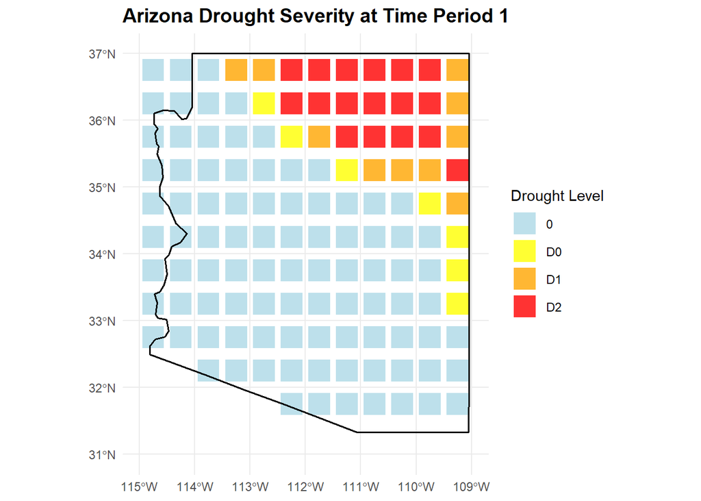

```r
library("ggplot2")
library("ggmap")
library("spData")
#Select one time period
time_choice <- 1 #select first time stamp
plot_data <- training[training$timeID == time_choice, ]

#convert to sf object
plot_sf <- st_as_sf(plot_data, coords = c("lon", "lat"), crs = 4326)

#Ensure droughtID is a factor (ordinal)
plot_sf$droughtID <- factor(
  plot_sf$droughtID,
  levels = c("0", "D0", "D1", "D2", "D3", "D4")
)

#Get Arizona boundary
data("us_states", package = "spData")
az_boundary <- us_states[us_states$NAME == "Arizona", ]
az_boundary <- st_transform(az_boundary, crs = 4326)

#Plot
ggplot() +
  geom_sf(
    data = plot_sf,
    aes(color = droughtID),
    size = 7,
    alpha = 0.8,
    shape = 15
  ) +
  scale_color_manual(
    values = c(
      "0" = "lightblue",
      "D0" = "yellow",
      "D1" = "orange",
      "D2" = "red",
      "D3" = "darkred",
      "D4" = "brown"
    ),
    name = "Drought Level"
  ) +
  geom_sf(
    data = az_boundary,
    fill = NA,
    color = "black",
    linewidth = 0.7
  ) +
  ggtitle(paste("Arizona Drought Severity at Time Period", time_choice)) +
  coord_sf(xlim = c(-115, -109), ylim = c(31, 37)) +
  theme_minimal() +
  theme(
    plot.title = element_text(size = 14, face = "bold"),
    legend.position = "right"
  )
```

## 5 Comparing single and two stage MCMC

Following the notation and explanation in Chapter 3 from Hepler et al., for location $i=1,\ldots,I$ and $t = 1,\ldots, T$, we have the following spatio-temporal model for ordinal data:

$$Y_{i,t} = \sum_{j=0}^J j\cdot I(\alpha_j < Z_{i,t} \leq \alpha_{j+1})$$

where $I(\text{condition})$ is the indicator function that returns 1 if the condition is true, 0 otherwise, $\alpha = (-\infty,\alpha_1,\alpha_2,\ldots,\alpha_J,\infty)$, and $Y_{i,t}\in \{0,1,\ldots,J\}$ which takes $J+1$ ordered levels. In our example, $J= 5$ with

$$Y_{i,t}\in\{0,1,2,3,4,5\} = \{0, D0, D1, D2, D3, D4\}$$
so $\alpha = (-\infty,0,1,2,3,4,\infty)$. The latent (unobserved) continuous drought process is

$$Z_{i,t} = \begin{cases}X_{i,t}{\beta}_i + \epsilon_{i,t}, &
\text{for } t = 1 \\[6pt]X_{i,t}{\beta}_i + \rho_i \big(Z_{i,t-1} -
X_{i,t-1}{\beta}_i\big) + \epsilon_{i,t}, & \text{for } t >
1,\end{cases}$$

where $X_{i,t}$ is a $(P+1)$-dimensional vector of covariates including the intercept parameter, $\beta_{i} = (\beta_{0i},\ldots,\beta_{Pi})$ is the location specific $(P+1)$-dimensional spatial random effect vector, $\rho_i$ is a spatial dependent autoregressive term, and errors $\epsilon_{i,t}\sim N(0,\sigma_i^2)$. In our example, $P=3$.

Let $\gamma_i = logit(\rho_i)$, $\theta_{Z,i} = (\beta_i,\gamma_i,\sigma_i^2)$ , and $\phi = (\sigma_\gamma^2,\{\sigma_p^2,p = 0,\ldots,P\})$.

In their paper, Hepler et al. assume $\beta_i$ and $\gamma_i$ independently follow intrinsic conditional autoregressive (ICAR) spatial models. The ICAR model is similar to the CAR model whereby they both analyze spatially correlated local dependency between random variables in areal (lattice) data. For these ICAR priors, we must calculate the adjacency matrix (Queen’s adjacency) based on the distance between each spatial coordinate.

Lastly, all variance parameters $\sigma_i^2, \sigma_\gamma^2, \text{and } \sigma_p^2$ follow inverse gamma prior distributions.

Putting this together, the full Bayesian hierarchical model of the spatio-temporal is:

$$\begin{aligned}\text{Data Model:} \quad & Y_{1:T} \mid Z_{1:T} \sim
f(Y_{1:T} \mid Z_{1:T}), \\[6pt]\text{Process Model:} \quad &
Z_{1:T} \mid {\theta}_Z, X_{1:T} \sim \pi(Z_{1:T} \mid {\theta}_Z,
X_{1:T}), \\[6pt]\text{Prior Models:} \quad & {\theta}_Z, {\phi}
\sim \pi({\theta}_Z \mid {\phi}) \pi({\phi}).\end{aligned}$$

The posterior distribution is:

$$\pi(Z_{1:T}, {\theta}_Z, {\phi} \mid Y_{1:T},
X_{1:T})\;\propto\;f(Y_{1:T} \mid Z_{1:T})\,\pi(Z_{1:T} \mid {\theta}_Z,
X_{1:T})\,\pi({\theta}_Z \mid {\phi})\,\pi({\phi})$$

For more details, please read chapter 3.1 in Hepler et al.’s paper.

With our data processing and model setup complete, our goal is to numerically estimate the posterior probability distribution of these unknown parameters using numerical sampling techniques called MCMC. If we didn’t have a computationally burdensome dataset, we can simply use a standard *single-stage* *Metropolis-within-Gibbs* MCMC approach (learn about it [here](https://georglsm.r-forge.r-project.org/site-projects/pdf/Hastings_within_Gibbs.pdf)). Otherwise, Hepler et al. suggests we use a two-stage approach, originally proposed by Lunn et al. [3], which they detail in chapter 3.2.

We make a comparison of single stage and two stage methodologies, following chapter 4 in Hepler et al.

### 5.1 Single Stage

The following implements the single-stage Metropolis-within-Gibbs MCMC algorithm which samples directly from the posterior distribution. Find the commented code that implements it in the Appendix.

Below we take the posterior mean and standard deviaiton of the samples of $\beta_i$.

```r
#Load data and prepare dataset
load("MCMCoutputStandard2.Rda")

#Create beta_array
samples_df = data.frame(samples[,])
n_iter <- nrow(samples)
beta_array <- array(NA, dim = c(Q, bp, n_iter))

for (j in 1:bp) {
  for (i in 1:Q) {
    col_name <- paste0("beta.", i, "..", j, ".")
    beta_array[i, j, ] <- samples_df[[col_name]]
  }
}

#Get mean of the posteriors
beta_avg1 <- apply(beta_array, c(1, 2), mean) #get mean of the posteirors
intercept_avg1 <- beta_avg1[,1]
evp_avg1 <- beta_avg1[,2]
soilm_avg1 <- beta_avg1[,3]
tsoil_avg1 <- beta_avg1[,4]

beta_sd1 <- apply(beta_array, c(1, 2), sd) #get sd of the posteirors
intercept_sd1 <- beta_sd1[,1]
evp_sd1 <- beta_sd1[,2]
soilm_sd1 <- beta_sd1[,3]
tsoil_sd1 <- beta_sd1[,4]
```

#### 5.1.1 Intercept

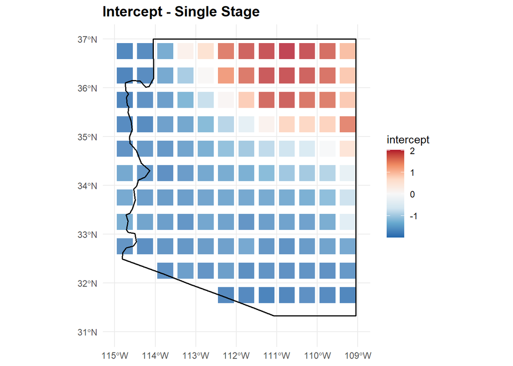

```r
#Combine intercept and coordinates
plot_df <- data.frame(
  lon = coords$lon,
  lat = coords$lat,
  intercept = intercept_avg1
)

#Convert to sf
plot_sf <- st_as_sf(plot_df, coords = c("lon", "lat"), crs = 4326)

#Plot
ggplot() +
  geom_sf(data = plot_sf, aes(color = intercept), size = 7, alpha = 0.8, shape = 15) +
  scale_color_distiller(
    palette = "RdBu",
    direction = -1
  )+
  geom_sf(data = az_boundary, fill = NA, color = "black", linewidth = 0.7) +
  ggtitle("Intercept - Single Stage") +
  coord_sf(xlim = c(-115, -109), ylim = c(31, 37)) +
  theme_minimal() +
  theme(
    plot.title = element_text(size = 14, face = "bold"),
    legend.position = "right"
  )
```

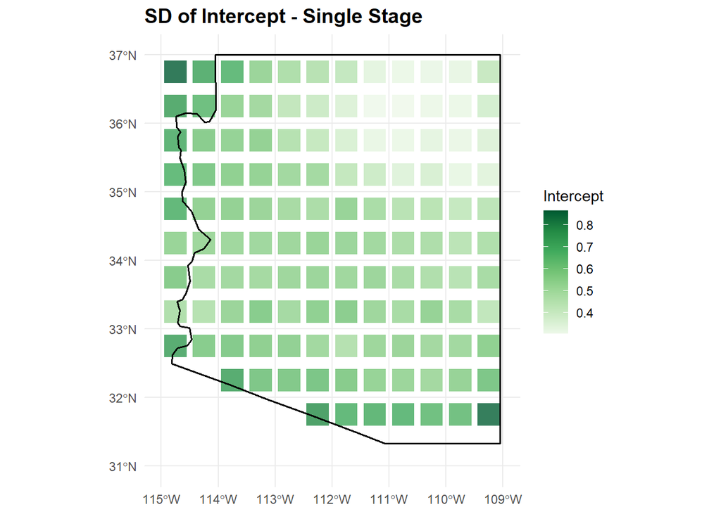

```r
#Combine intercept and coordinates
plot_df <- data.frame(
  lon = coords$lon,
  lat = coords$lat,
  Intercept = intercept_sd1
)

#Convert to sf
plot_sf <- st_as_sf(plot_df, coords = c("lon", "lat"), crs = 4326)

#Plot
ggplot() +
  geom_sf(data = plot_sf, aes(color = Intercept), size = 7, alpha = 0.8, shape = 15) +
  scale_color_distiller(
    palette = "Greens",
    direction = 1
  )+
  geom_sf(data = az_boundary, fill = NA, color = "black", linewidth = 0.7) +
  ggtitle("SD of Intercept - Single Stage") +
  coord_sf(xlim = c(-115, -109), ylim = c(31, 37)) +
  theme_minimal() +
  theme(
    plot.title = element_text(size = 14, face = "bold"),
    legend.position = "right"
  )
```

**Note:** To save on space and improve readability, for the remaining plots in this section we omit their corresponding code because they’re almost identical.

#### 5.1.2 Evapotranspiration

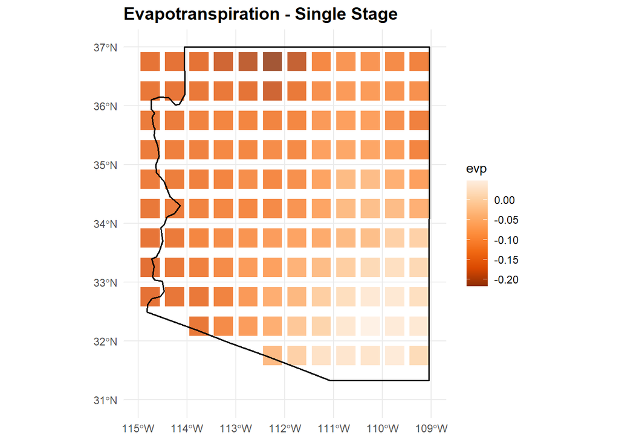

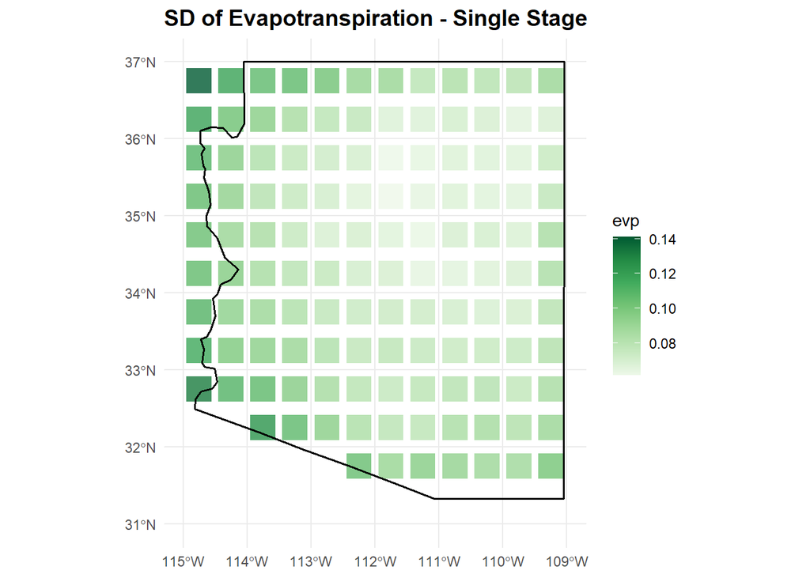

#### 5.1.3 Soil Moisture

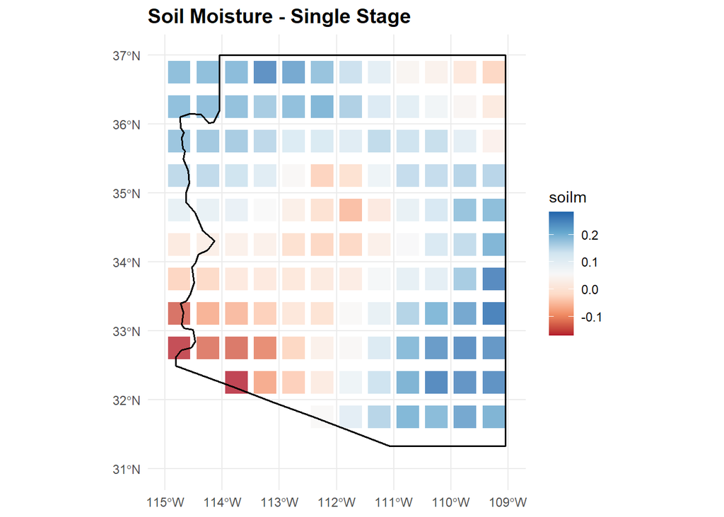

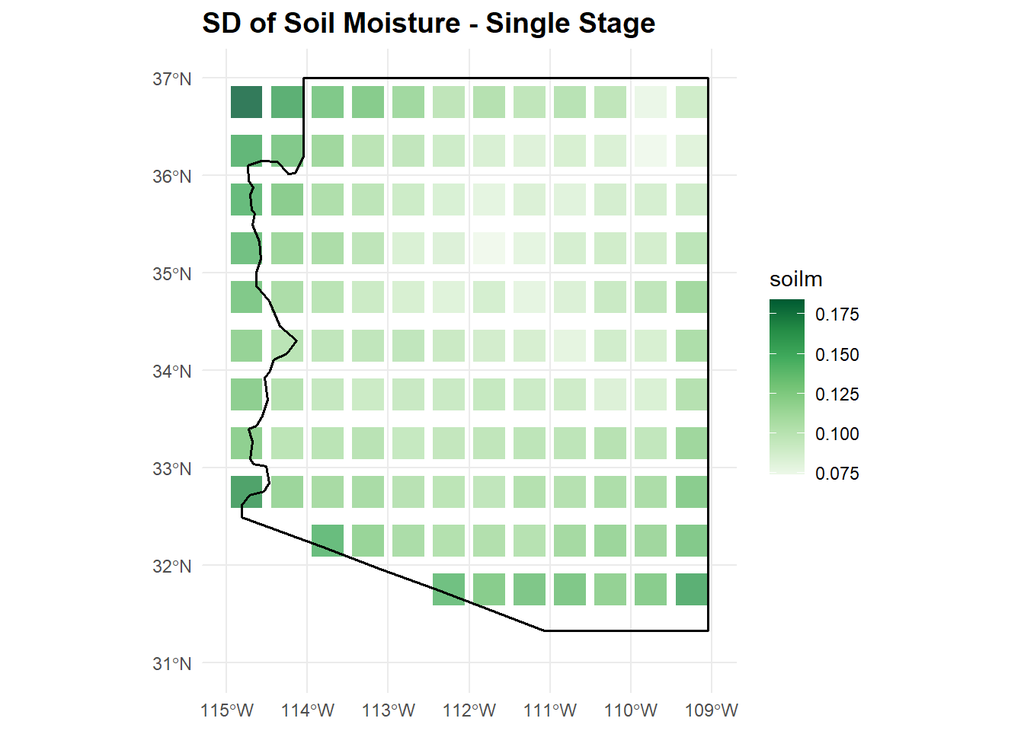

#### 5.1.4 Soil Temperature

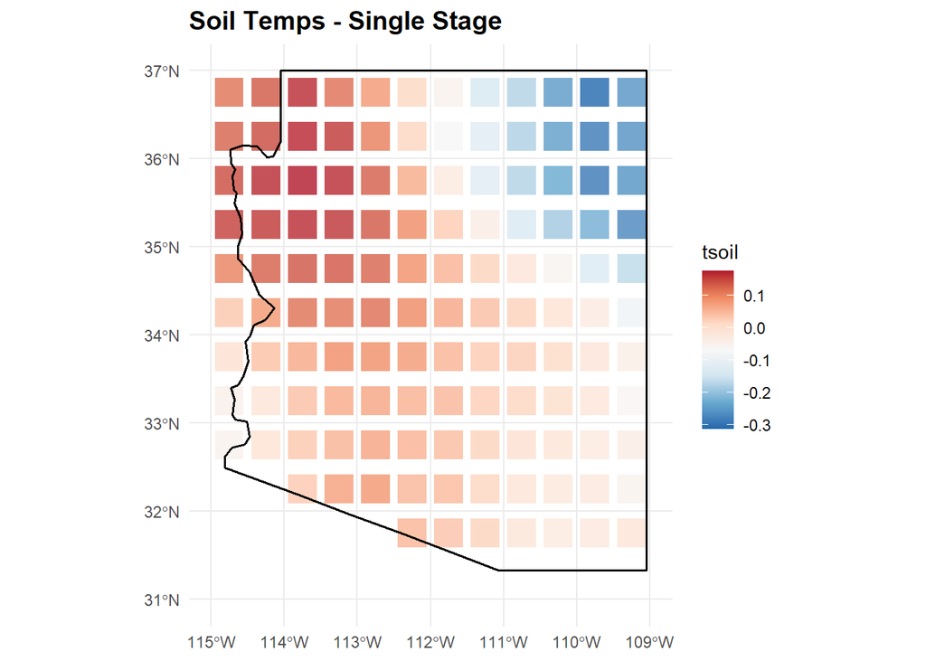

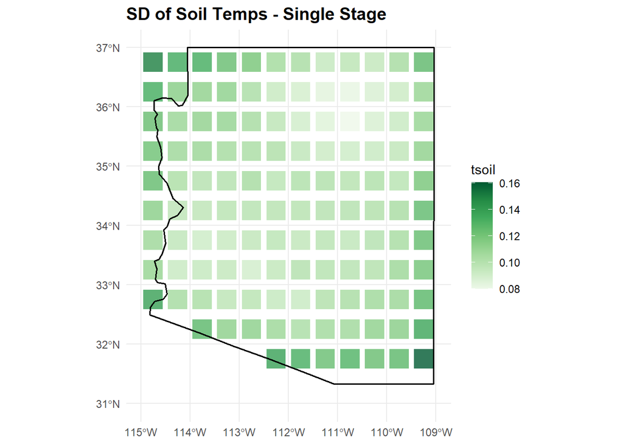

### 5.2 Two stage

The following implements the two-stage MCMC algorithm. In practice, we would’ve used an HPC for stage one of the algorithm to take full advantage of the parallel nature of this method, whereby we run an MCMC sampler for each parameter at each spatial location. However, as this is only a demonstration, we ran the code sequentially using a for loop on a local machine. Regardless, after stage 1, re-sampling all the individual samples in stage 2 is fast and can be done locally. Find the commented code that implements it in the Appendix.

Below we take the posterior mean and standard deviaiton of the samples of $\beta_i$.

```r
#Load data and prepare dataset
load("Stage2Output.Rda")
avg_beta2 <- apply(beta.out, c(1, 2), mean) #get mean of the posteirors
sd_beta2 <- apply(beta.out, c(1, 2), sd) #get sd of the posteriors

intercept_avg2 <- avg_beta2[,1]
evp_avg2 <- avg_beta2[,2]
soilm_avg2 <- avg_beta2[,3]
tsoil_avg2 <- avg_beta2[,4]

intercept_sd2 <- sd_beta2[,1]
evp_sd2 <- sd_beta2[,2]
soilm_sd2 <- sd_beta2[,3]
tsoil_sd2 <- sd_beta2[,4]
```

#### 5.2.1 Intercept

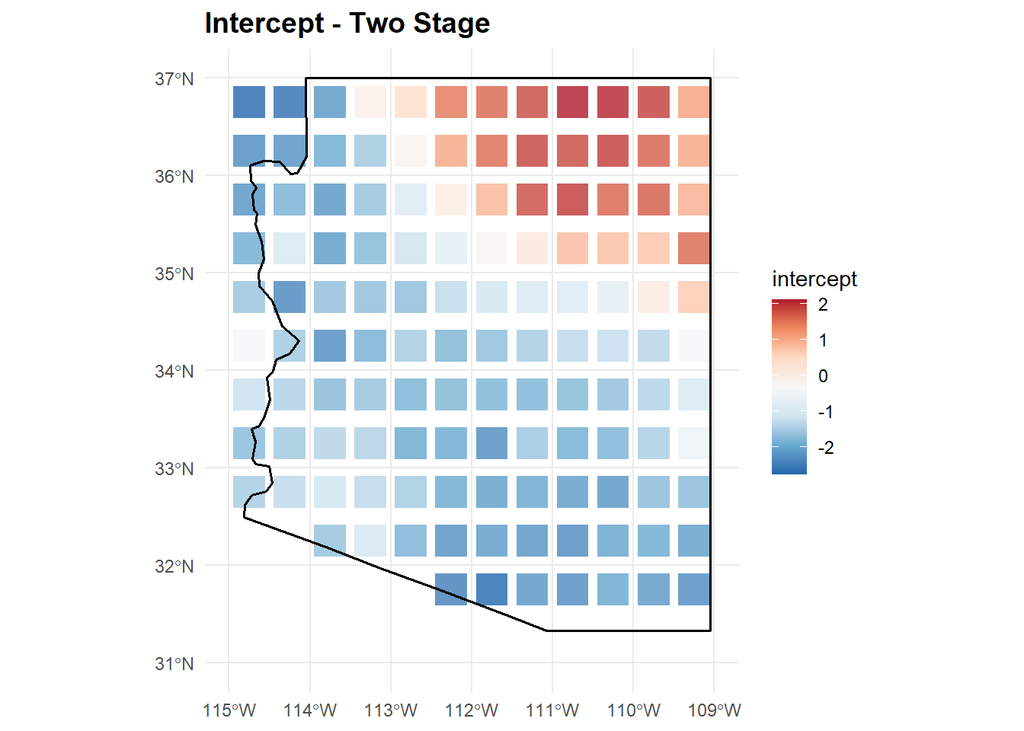

```r
#Combine intercept and coordinates
plot_df <- data.frame(
  lon = coords$lon,
  lat = coords$lat,
  intercept = intercept_avg2
)

#Convert to sf
plot_sf <- st_as_sf(plot_df, coords = c("lon", "lat"), crs = 4326)

#Plot
ggplot() +
  geom_sf(data = plot_sf, aes(color = intercept), size = 7, alpha = 0.8, shape = 15) +
  scale_color_distiller(
    palette = "RdBu",
    direction = -1
  )+
  geom_sf(data = az_boundary, fill = NA, color = "black", linewidth = 0.7) +
  ggtitle("Intercept - Two Stage") +
  coord_sf(xlim = c(-115, -109), ylim = c(31, 37)) +
  theme_minimal() +
  theme(
    plot.title = element_text(size = 14, face = "bold"),
    legend.position = "right"
  )
```

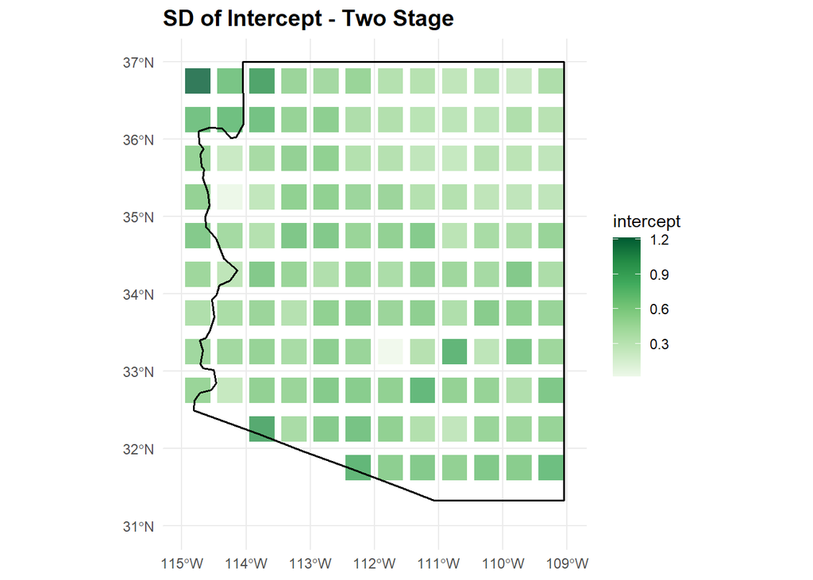

```r
#Combine intercept and coordinates
plot_df <- data.frame(
  lon = coords$lon,
  lat = coords$lat,
  intercept = intercept_sd2
)

#Convert to sf
plot_sf <- st_as_sf(plot_df, coords = c("lon", "lat"), crs = 4326)

#Plot
ggplot() +
  geom_sf(data = plot_sf, aes(color = intercept), size = 7, alpha = 0.8, shape = 15) +
  scale_color_distiller(
    palette = "Greens",
    direction = 1
  )+
  geom_sf(data = az_boundary, fill = NA, color = "black", linewidth = 0.7) +
  ggtitle("SD of Intercept - Two Stage") +
  coord_sf(xlim = c(-115, -109), ylim = c(31, 37)) +
  theme_minimal() +
  theme(
    plot.title = element_text(size = 14, face = "bold"),
    legend.position = "right"
  )
```

**Note:** To save on space and improve readability, for the remaining plots in this section we omit their corresponding code because they’re almost identical.

#### 5.2.2 Evapotranspiration

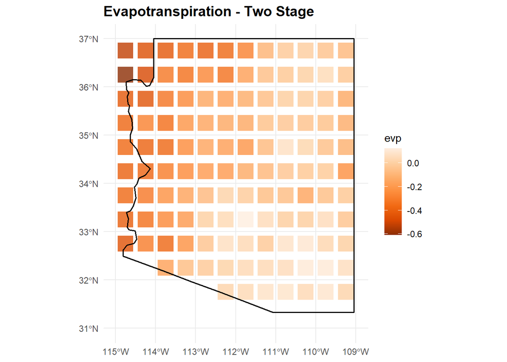

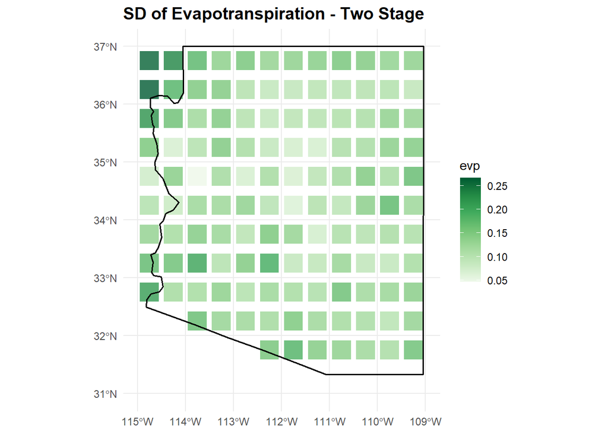

#### 5.2.3 Soil Moisture

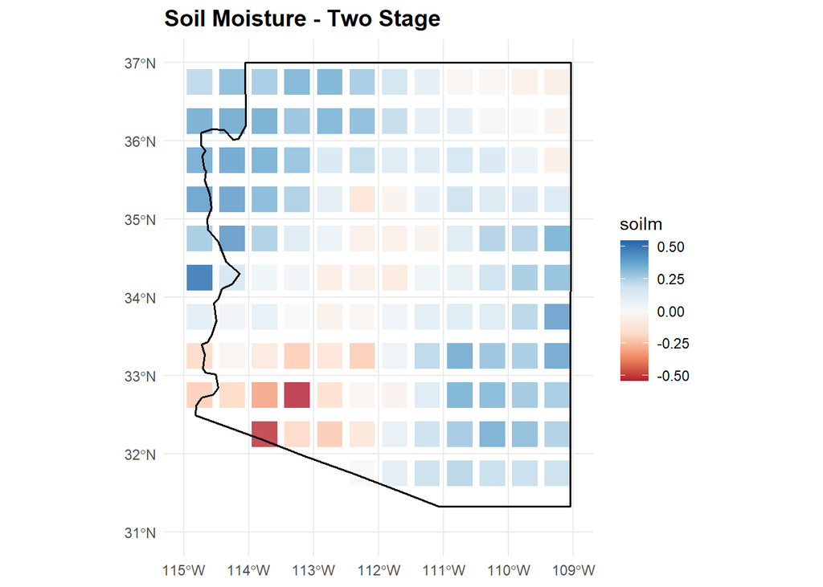

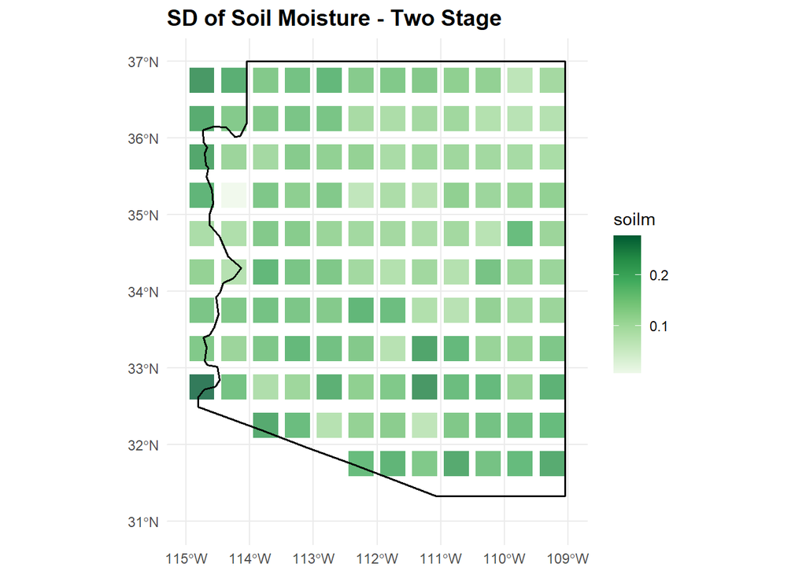

#### 5.2.4 Soil Temperature

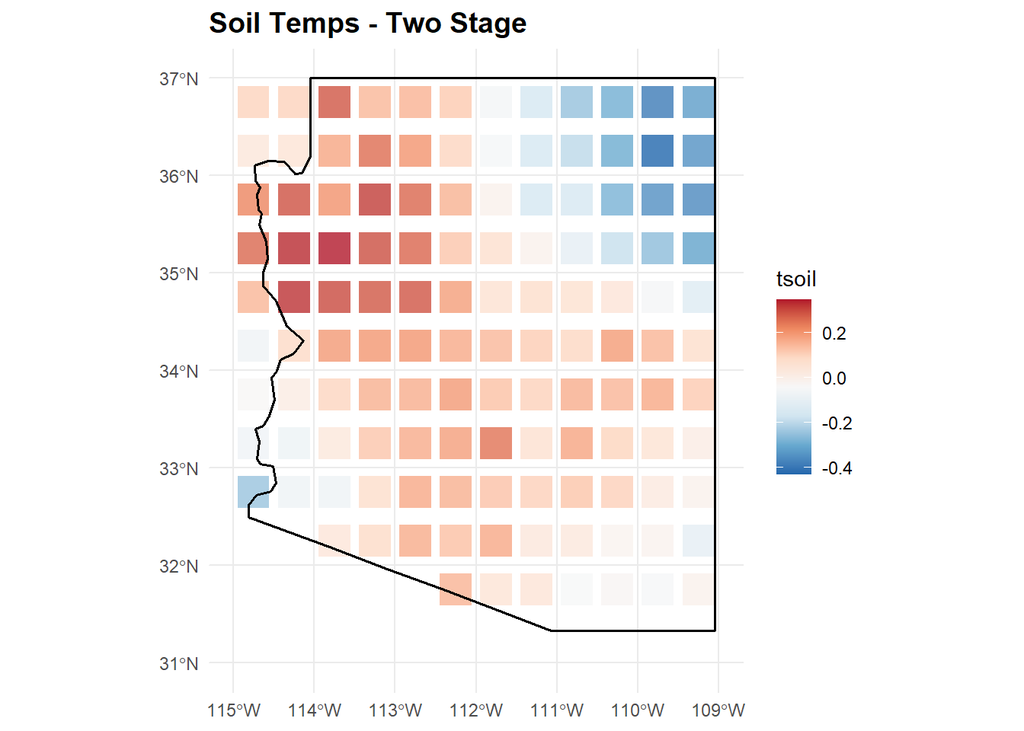

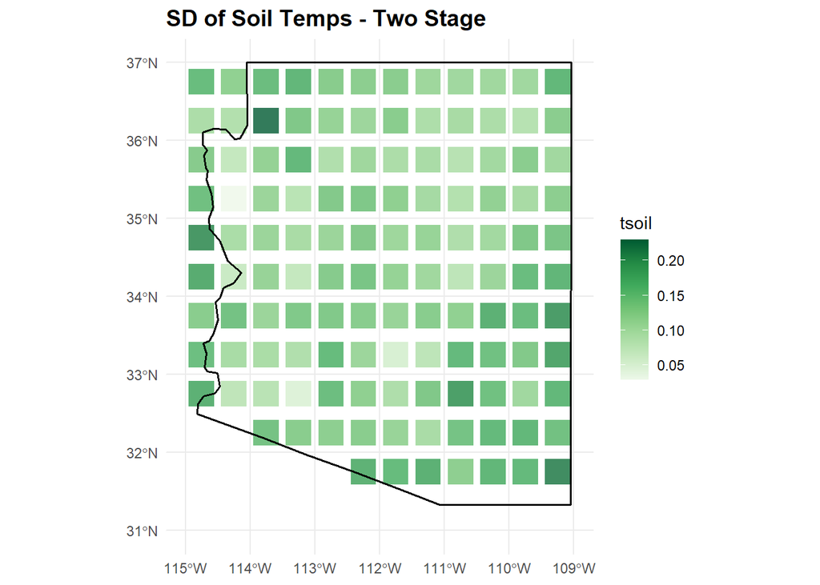

## 6 Conclusions

Comparing the effect of each of parameter in $\beta_i$ to the ordinal drought level at each grid location $i$ in Arizona, the single stage and the two stage MCMC algorithms produced visually similar plots. However, we note the following limitations of the two-stage method:

- the plot of each parameter’s standard deviations appear slightly higher overall than in the single stage. This is to be expected given that we’re not sampling all-at-once.
- Hepler et al. mention that since stage 2 uses a regular Metropolis-Hastings update, jointly updating a high-dimensional parameter could greatly lower a sample’s acceptance rate. This poor mixing means the MCMC struggles to find other suitable samples in the parameter space.
- they also mention that the quality of the samples in stage 2 greatly depend on the quality of samples in stage 1. Quality samples means that stage 1 explored the entire parameter space.

Despite these potential drawbacks, in this demonstration we observed only small differences between the samples produced from single and two stage. Assuming our dataset is not too high-dimensional soas to produce poor mixing mentioned above, we recommend the two stage approach because it

- is computationally efficient due to its potential for parallelization in stage 1.
- has real-world applications for very large spatio-temporal data sets.

## 7 References

1. Erhardt, R., DiVittorio, C. A., Hepler, S. A., Lowman, L. E. L., & Wei, W. (2024). *Homogenized gridded dataset for drought and hydrometeorological modeling for the continental United States*. Scientific Data, 11, Article 375.
2. Hepler, S., & Erhardt, R. (2025). *Two-stage MCMC for fast Bayesian inference of large spatio-temporal ordinal data, with application to US drought*. arXiv preprint
3. Lunn, D., Barrett, J., Sweeting, M., and Thompson, S. *Fully Bayesian hierarchical mod- elling in two stages, with application to meta-analysis*. Journal of the Royal Statistical Society. Series C, Applied Statistics, 62(4):551 (2013).

## 8 Appendix

As we’re not seeking the most accurate results in this demonstration, please note the following important modifications to the Hepler et al.’s code to increase computational efficiency. In both the single stage and two stage implementations, rather than slice sampling we use a random walker sampler along with fewer sample iterations.

### 8.1 Single Stage

Following Hepler et al.’s code [here](https://github.com/heplersa/DroughtModelTwoStageMCMC/blob/main/ComparisonStudy/MCMCstandard.R).

```r
# --- 1 ---
#Load libraries
library("nimble")
library("coda")

# --- 2 ---
#Initial values
alpha <- c(-Inf,0,1,2,3,4,Inf) #response thresholds
tau.z <- rep(1,Q) #init latent variable precision
Z <- 1*(Y - 0.5) #latent Gaussian var, initialized using transformation of Y
beta <- matrix(NA,Q,bp) #regression coefficients per grid cell. QXbp.

#Initialize beta using OLS:
for(q in 1:Q) {
  beta[q,] <- lm(Z[q,] ~ X[seq(q,(Q*Tobs),by=Q),]-1)$coefficients
  beta[q,which(is.na(beta[q,]))] <- 0
}

#Initialize another param
rho.Z <- rep(.95,Q)

# --- 3 ---
#Compute adjacency matrix based on dist btwn spat coords
A <- as.matrix(dist(coords))
A <- 1*((A <= sqrt(0.5)) & (A > 0)) #Queen's adjacency
num <- colSums(A) #number of neighbors for each grid cell

#Vectorize for NIMBLE
adj <- NULL
for(j in 1:Q) {
  adj <- c(adj,which(A[j,]==1))
}
adj <- as.vector(adj)
num <- as.vector(num)
weights <- 1+0*adj

# --- 4 ---
#Setup MCMC
M.iter <- 10000
M.burn <- 2000
M.thin <- 5

#NIMBLE model setup
mod_data <- list(
  Y = Y,
  X = X
)
mod_constants <- list(
  Tobs = Tobs,
  Q = Q,
  bp = bp,
  cut = c(0,1,2,3,4),
  adj = adj,
  num = num,
  weights = weights
)
mod_inits <- list(
  beta = beta,
  l.rho.z = log(rho.Z/(1-rho.Z)),
  tau.z = tau.z, Z=1*(Y-.5)
)

#Model code
model_code=nimbleCode({
  for(q in 1:Q){
    #t = 1
    mu[q,1] <- inprod(X[q,1:bp],beta[q,1:bp])
    Z[q,1] ~ dnorm(mu[q,1], tau = tau.z[q])
    Y[q,1] ~ dinterval(Z[q,1], cut[])

    #t > 1
    for(t in 2:Tobs){
      mu[q,t] <- inprod(X[Q*(t-1)+q,1:bp],beta[q,1:bp]) +
        rho.z[q]*
        (Z[q,(t-1)]-(inprod(X[Q*(t-2)+q,1:bp], beta[q,1:bp])))
      Z[q,t] ~ dnorm(mu[q,t], tau = tau.z[q])
      Y[q,t] ~ dinterval(Z[q,t], cut[])
    }
  }

  #ICAR priors for each beta
  for(p in 1:bp){
    beta[1:Q,p] ~ dcar_normal(adj[], weights[], num[], tau.b[p], zero_mean=0)
    tau.b[p] ~ dgamma(.01,.01)
  }

  #ICAR prior for logit(rho.z)
  l.rho.z[1:Q] ~ dcar_normal(adj[], weights[], num[], tau.lr, zero_mean=0)
  tau.lr ~ dgamma(.01,.01)

  for (q in 1:Q) {
    rho.z[q] <- exp(l.rho.z[q])/(1+exp(l.rho.z[q]))
    tau.z[q] ~ dgamma(.01,.01)
  }
})

#Compile & configure MCMC
nimble_model <- nimbleModel(model_code, mod_constants, mod_data, mod_inits)
compiled_model <- compileNimble(nimble_model,resetFunctions = TRUE)
mcmc_conf <- configureMCMC(
  nimble_model,
  monitors = c('beta','rho.z','tau.z','Z'),
  control = list(
    adaptive = TRUE, #enable adaptive tuning of sampler step sizes during burn-in
    scale = 0.1, #initial scale for adaptive sampler
    adaptInterval = 100, #update sampler tuning every 100 iter
    sliceMaxSteps = 100000,
    maxContractions = 100000,
    sliceWidth = 1
  ),
  useConjugacy = TRUE
)

# --- 5 ---
#Build & compile
st1 <- Sys.time()
nimble_mcmc <- buildMCMC(mcmc_conf)
compiled_mcmc <- compileNimble(
  nimble_mcmc,
  project = nimble_model,
  resetFunctions = TRUE
)

# --- 6 ---
#Run MCMC
st2 <- Sys.time()

samples = runMCMC(
  compiled_mcmc,
  inits = mod_inits,
  nchains = 1,
  nburnin = M.burn,
  niter = M.iter,
  samplesAsCodaMCMC = TRUE,
  thin = M.thin,
  summary = FALSE,
  WAIC = FALSE,
  progressBar = TRUE
)

time.out.total <- Sys.time() - st1
time.out.run <- Sys.time() - st2

save(
  samples,
  time.out.total,
  time.out.run,
  file = "MCMCoutputStandard2.Rda"
)
```

### 8.2 Two stage

#### 8.2.1 Stage 1

Following Hepler et al.’s code [here](https://github.com/heplersa/DroughtModelTwoStageMCMC/blob/main/ComparisonStudy/MCMCstage1.R)

```r
# --- 1 ---
#now can do MCMC for grid cell q
st<- Sys.time()

#running as array job; this picks the individual grid used in each part of the array
for(q in 1:Q) {

  #extract design matrix and response variable for this grid cell
  II = seq(q,(Q*Tobs),by=Q)
  X = cbind(rep(1,Tobs),Xfull[II,])
  Y = yfull[II]

  D = 5 #6 total drought levels
  bp = dim(X)[2]

  # --- 2 ---
  #set initial values
  alpha = c(-Inf,0,1,2,3,4,Inf)
  tau.z = 1
  Z = 1*(Y - 0.5)

  #use the AR(1) estimates as initial values for model parameters
  fit = arima(Z,order=c(1,0,0),xreg=X[,2:4])
  rho.Z = fit$coef[1]
  beta = fit$coef[2:5]
  #if outputs NA give different initial values
  if(is.na(sum(beta))){
    beta[1] = Z
    beta[2:ncol(X)]=0
    rho.Z=.98
  }

  ## --- 3 ---
  #Set up MCMC
  M.iter <- 10000
  M.burn <- 2000
  M.thin <- 4

  mod_data <- list(
    Y=Y,
    X=X
  )
  mod_constants <- list(
    Tobs = Tobs,
    bp=bp,
    cut=c(0,1,2,3,4)
  )
  mod_inits <- list(
    beta = beta,
    rho.z = rho.Z,
    tau.z = tau.z,
    Z = 1*(Y-.5)
  )

  # --- 4 ---
  #Model code
  model_code <- nimbleCode({
    #Drought Variable
    for(t in 1:Tobs){
      Y[t] ~ dinterval(Z[t], cut[])
    }

    #Latent Gaussian Variable
    mu[1] <- inprod(X[1,1:bp],beta[1:bp])
    Z[1] ~ dnorm(mu[1], tau = tau.z)
    for(t in 2:Tobs){
      mu[t] <- inprod(X[t,1:bp],beta[1:bp]) +
        rho.z*(Z[(t-1)] - (inprod(X[(t-1),1:bp], beta[1:bp])))
      Z[t] ~ dnorm(mu[t], tau = tau.z)
    }

    #prior distribution for beta, i indexes each element of beta
    for (b in 1:bp){
      beta[b] ~ dnorm(0, tau = 1/9)
    }

    #prior distribution for tau.z
    tau.z ~ dgamma(0.01, 0.01)

    #prior distribution for rho, not rho ~ U(0,1) = gamma ~ logistic(0,1)
    gamma ~ dlogis(0,1)
    rho.z <- exp(gamma)/(1+exp(gamma))
  })

  nimble_model <- nimbleModel(
    model_code,
    mod_constants,
    mod_data,
    mod_inits
  )

  # --- 5 ---
  #Compile MCMC
  compiled_model <- compileNimble(
    nimble_model,
    resetFunctions = TRUE
  )
  mcmc_conf <- configureMCMC(
    nimble_model,
    monitors = c('beta','rho.z','tau.z','Z'),
    control = list(
      adaptive=TRUE,
      scale=0.1,
      adaptInterval=100,
      sliceMaxSteps=100000,
      maxContractions=100000,
      sliceWidth=1),
    useConjugacy = TRUE
  )

  #change sampler for Z to an AF slice sampler
  #mcmc_conf$removeSamplers("Z")
  #mcmc_conf$addSampler(target="Z",type='AF_slice')

  nimble_mcmc <- buildMCMC(mcmc_conf)
  compiled_mcmc <- compileNimble(
    nimble_mcmc,
    project = nimble_model,
    resetFunctions = TRUE
  )

  # --- 6 ---
  #Run samples
  samples = runMCMC(
    compiled_mcmc,
    inits = mod_inits,
    nchains = 1,
    nburnin = M.burn,
    niter = M.iter,
    samplesAsCodaMCMC = TRUE,
    thin = M.thin,
    summary = FALSE,
    WAIC = FALSE,
    progressBar = TRUE
  )

  time.out <- Sys.time() - st

  zl = which(colnames(samples) == "Z[1]")
  zu = which(colnames(samples) == paste("Z[",Tobs,"]",sep=""))
  bl = which(colnames(samples) == "beta[1]")
  bu = which(colnames(samples) == paste("beta[",bp,"]",sep=""))
  rl = which(colnames(samples) == "rho.z")
  tl = which(colnames(samples) == "tau.z")

  MCMCout <- list(
    "Z" = samples[,zl:zu],
    "sigma.sq" = 1/samples[,tl],
    "beta" = samples[,bl:bu],
    "rho.Z"=samples[,rl]
  )

  #save output for each stage one posterior in a folder indexed by site ID
  save(MCMCout, time.out, file = paste("StageOneOutput/MCMCout.",q,".Rda",sep=""))
}
```

#### 8.2.2 Stage 2

Following Hepler et al.’s code [here](https://github.com/heplersa/DroughtModelTwoStageMCMC/blob/main/ComparisonStudy/MCMCstage2.R)

```r
# --- 1 ---
#Load libs
library(invgamma)
library(mvtnorm)

# --- 2 ---
#load in all samples from the 1-stage model and consolidate the stage 1 output
load(paste('StageOneOutput/MCMCout.',1,'.Rda',sep=""))

n <- Q
T <- ncol(MCMCout$Z)
M <- nrow(MCMCout$Z)

Z.samp <- array(NA,c(n,T,M))
sigma.sq.samp <- matrix(NA,n,M)
beta.samp <- array(NA,c(n,dim(MCMCout$beta)[2],M))
rho.Z.samp <- matrix(NA,n,M)

for(q in 1:n){
    load(paste('StageOneOutput/MCMCout.',q,'.Rda',sep=""))
    Z.samp[q,,] = t(MCMCout$Z)
  sigma.sq.samp[q,] = MCMCout$sigma.sq
  beta.samp[q,,] = t(MCMCout$beta)
  rho.Z.samp[q,] = MCMCout$rho.Z
    rm('MCMCout')
}

# convert rho.Z to gamma samples
gamma.samp = log(rho.Z.samp/(1-rho.Z.samp))

# --- 3 ---
#need to construct adjacency matrix
#need adjacency matrix for grid cells and number of neighbors of each...

loc <- data[which(data$time==data$time[1]),c("lon","lat")]
D <- as.matrix(dist(loc))
A <- 1*(D>0 & D<=sqrt(.5)) ### regular grid; queens adjacency means distances is <= sqrt(0.5)
numnns <- rowSums(A)
D <- matrix(0,n,n)
diag(D) <- numnns


# --- 4 ---
#run the second stage MCMC algorithm

#set initial values
#take one draw for each site-specific parameter
Z <- Z.samp[,,M]
sigma.sq <- sigma.sq.samp[,M]
beta <- beta.samp[,,M]
gamma <- gamma.samp[,M]

bp <- dim(beta.samp)[2]

#initial values for overall parameters
tausq.b <- rep(1,bp)
tausq.g <- 1


#store final draws
M.iter <- 10000
M.burn <- 2000
M.thin <- 5
M.out <- (M.iter-M.burn)/M.thin

Z.out <- array(NA,c(n,T,M.out))
sigma.sq.out <- matrix(NA,n,M.out)
beta.out <- array(NA,c(n,bp,M.out))
rho.Z.out <- matrix(NA,n,M.out)
tausq.b.out <- matrix(NA,bp,M.out)
tausq.g.out <- rep(NA,M.out)

progress_bar <- txtProgressBar(min=0, max=M.iter, style = 3, char="=")
for(m in 1:M.iter){
  #update tausq.b for each covariate
  for(p in 1:bp){
    tausq.b[p] = rinvgamma(1,0.5+n/2,0.5+1/2*t(beta[,p])%*%(D-A)%*%beta[,p])   #sum((beta[,p]-beta0[p])^2)  )
  }
  #update tausq.g
  tausq.g = rinvgamma(1,0.5+n/2,0.5+1/2*t(gamma)%*%(D-A)%*%gamma)

  #update the site-specific parameters for each location
  #update full vector of site-specific parameters jointly
  for(i in 1:n){
    mi = sample(1:M,1) #sample a stage 1 draw randomly
    gamma.new = gamma.samp[i,mi]
    gammam = 1/numnns[i]*A[i,]%*%gamma #mean of ICAR conditional distribution = average of neighbors
    betap.new = beta.samp[i,,mi]
    betam = 1/numnns[i]*A[i,]%*%beta
    R.new = dnorm(gamma.new,gammam,sd=sqrt(tausq.g/numnns[i]),log=TRUE)+sum(dnorm(betap.new,betam,sqrt(tausq.b/numnns[i]),log=TRUE))-dlogis(gamma.new,0,1,log=TRUE)-sum(dnorm(betap.new,0,sd=3,log=TRUE))
    R.old = dnorm(gamma[i],gammam,sd=sqrt(tausq.g/numnns[i]),log=TRUE)+sum(dnorm(beta[i,],betam,sqrt(tausq.b/numnns[i]),log=TRUE ))-dlogis(gamma[i],0,1,log=TRUE)-sum(dnorm(beta[i,],0,sd=3,log=TRUE))

    if(log(runif(1))<(R.new-R.old)){
      gamma[i] = gamma.new
      sigma.sq[i] = sigma.sq.samp[i,mi]
      Z[i,] = Z.samp[i,,mi]
      beta[i,] = betap.new
    }
  }

  if(m>=M.burn & m/M.thin==floor(m/M.thin)){
    Z.out[,,(m-M.burn)/M.thin] = Z
    sigma.sq.out[,(m-M.burn)/M.thin] = sigma.sq
    beta.out[,,(m-M.burn)/M.thin] = beta
    rho.Z.out[,(m-M.burn)/M.thin] = exp(gamma)/(1+exp(gamma))
    tausq.b.out[,(m-M.burn)/M.thin] = tausq.b
    tausq.g.out[(m-M.burn)/M.thin] = tausq.g
  }
  setTxtProgressBar(progress_bar, value = m)
}
close(progress_bar)
time.out <- Sys.time()-st

save(time.out,Z.out,sigma.sq.out,beta.out,rho.Z.out,tausq.b.out,tausq.g.out,file="Stage2Output.Rda")
```